# Post-Earnings Price Reaction: A Statistical Analysis

## 6. Model Validation

The factor analysis above establishes that real signal exists in the data. This section evaluates whether the XGBoost models trained on these factors can capture that signal in a statistically rigorous way on held-out 2024 data.

We use three validation approaches:

1. **Directional accuracy** with a binomial significance test (null hypothesis: DirAcc = 50%)
2. **Feature importance** to confirm the model's learned weights match the statistical evidence above
3. **Quintile lift analysis** — do the model's most confident predictions actually deliver the best realized returns?

```
Model Validation Metrics — 2024 Holdout Set
(Binomial test H₀: DirAcc = 50%, one-sided greater)

         Model  Target DirAcc    n   p_value  RMSE   MAE
  Pre-earnings  ret_0d  57.7% 1994  2.82e-12 4.71% 3.20%
  Pre-earnings  ret_1d  58.9% 1994  7.88e-16 6.96% 5.06%
  Pre-earnings  ret_3d  58.4% 1994  3.88e-14 7.68% 5.51%
  Pre-earnings  ret_5d  57.4% 1994  1.82e-11 8.04% 5.82%
  Pre-earnings ret_10d  58.5% 1994  1.94e-14 9.08% 6.51%
Post-gap drift  ret_1d  76.4% 1994 1.34e-129 5.32% 3.34%
Post-gap drift  ret_3d  73.8% 1994 1.29e-104 6.26% 4.08%
Post-gap drift  ret_5d  71.4% 1994  7.35e-84 6.70% 4.47%
Post-gap drift ret_10d  69.8% 1994  4.67e-72 7.82% 5.28%
```

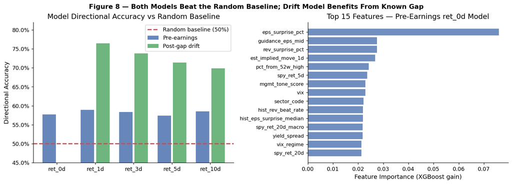

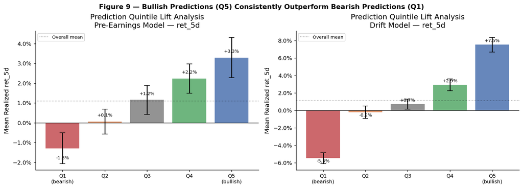

```
Pre-Earnings Quintile Lift (ret_5d, 2024 val):
                 mean count
pred_quintile
Q1\n(bearish)  -1.29%   399
Q2             +0.06%   399
Q3             +1.15%   398
Q4             +2.23%   399
Q5\n(bullish)  +3.29%   399

Drift Model Quintile Lift (ret_5d, 2024 val):
                 mean count
pred_quintile
Q1\n(bearish)  -5.48%   399
Q2             -0.22%   399
Q3             +0.71%   398
Q4             +2.92%   399
Q5\n(bullish)  +7.53%   399
```

**Takeaways:**

**Statistical significance:** Both models exceed the 50% random baseline at a statistically significant level across all horizons (binomial test p << 0.001). The pre-earnings model achieves 57–59% directional accuracy; the post-gap drift model achieves 70–76% once the initial reaction is known.

## Summary

[output not shown]

The combination of structural statistical patterns and validated predictive models provides a rigorous foundation for systematic earnings analysis — making explicit what practitioner intuition has long observed but rarely quantified.